# Reproducible Research - Activity Monitoring (Project 1 Resubmission)

================================================================================

There is a rise in the so-called “quantified self” movement, where people track their physical activity and collect large data sets in order to find patterns about themselves in pursuit of self-improvement.

However, there are often large sets of raw data being collected that are not processed, and as a result often go under-utilized.

In this project, data from an anonymous individual were collected over a two-month time period in October and November 2012 using a personal activity monitoring device.

## - Loading and Transforming Activity Monitoring Data

```r
echo = TRUE
# Load ggplot2 functions

library(ggplot2)

# When the .csv file is in your local R/RStudio directory and already unzipped:

ActMon <- read.csv("/Users/alex/Desktop/Coursera/Reproducible_Research/activity.csv")
```

These data contain the following three variables:

- steps (5-minute interval inclusive of the number of steps)
- date (YYYY-MM-DD format for when data were collected)
- interval (identifies the particular time interval data were collected)

The following questions have been addressed in this markdown document:

## - What is the mean total number of steps taken per day?

```r
echo = TRUE
# Find the total number of steps taken per day, then summary to find the
# Mean and Median at the same time, along with other distribution data

T_Steps <- aggregate(steps ~ date, ActMon, sum)
print(summary(T_Steps))
```

```
##      date               steps
##  Length:53          Min.   :   41
##  Class :character   1st Qu.: 8841
##  Mode  :character   Median :10765
##                     Mean   :10766
##                     3rd Qu.:13294
##                     Max.   :21194
```

## - How does the distribution of values for total number of steps change

## over the course of the period in quesion?

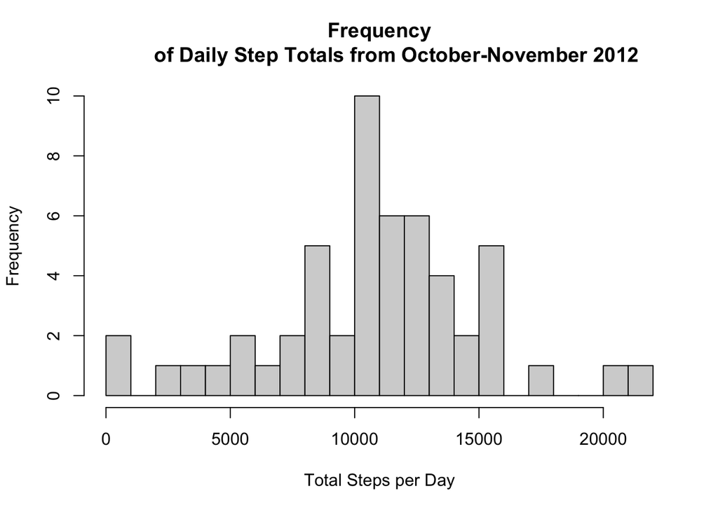

```r
echo = TRUE
# Simple histogram demonstrating the number of steps was close to Mean/Median

hist(T_Steps$steps, breaks = 16, xlab = "Total Steps per Day", main = "Frequency
      of Daily Step Totals from October-November 2012")
```

## 3. What is the average daily activity pattern for this individual like?

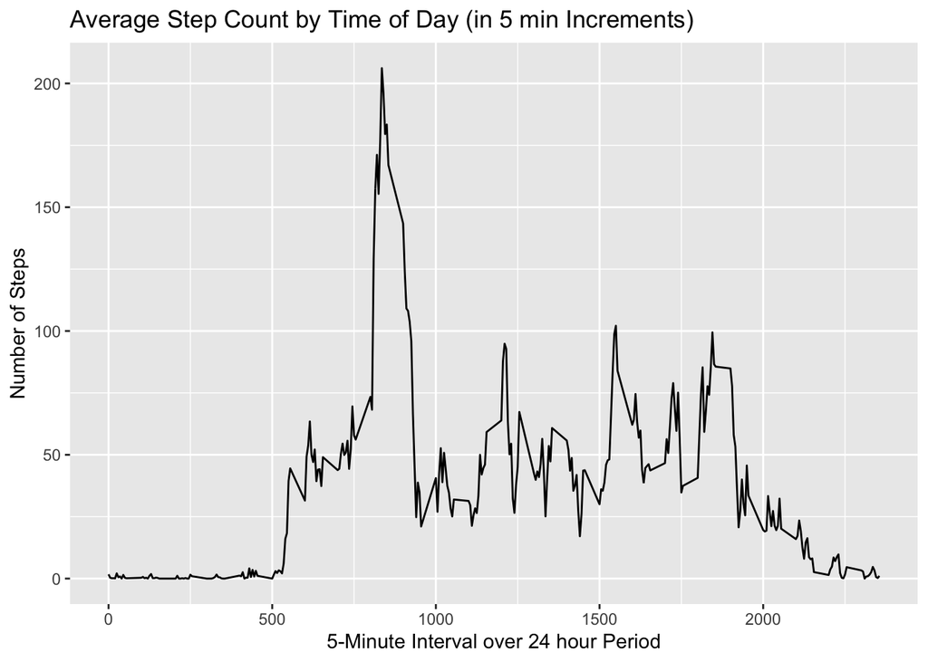

```r
echo = TRUE
# Compute the mean of all steps based on the interval in which they occurred,
# then save the output as an object
Int_Act <- aggregate(steps ~ interval, ActMon, mean)

# Plot the average activity pattern seen in a 24-hour period of time
ggplot(data = Int_Act) +
  geom_line(aes(interval,steps)) +
  xlab("5-Minute Interval over 24 hour Period") +
  ylab("Number of Steps") +
  ggtitle("Average Step Count by Time of Day (in 5 min Increments)")
```

## - At what 5-interval point is the highest average number of steps taken?

```r
echo = TRUE
# Display the interval where most number of average steps are taken

print(Int_Act[which.max(Int_Act$steps),])
```

```
##     interval    steps
## 104      835 206.1698
```

We can see in the 835 interval that the highest average number of steps is about 206.

## - How many entries are missing data?

```r
echo = TRUE
# Determining the total missing values by the total number flagged by the
# system

print(colSums(is.na(ActMon)))
```

```
##    steps     date interval
##     2304        0        0
```

There are 2,304 steps entries that are NA.

## - What do the data look like when missing values are changed to the original

## data’s mean or median values?

```r
echo = TRUE
# Start transforming NA values in steps into the mean of the original data set
# for values in the original data set where NA values are present

ActMon -> ActMon2

ActMon2$steps <- ifelse(is.na(ActMon2$steps) == TRUE,
                      Int_Act$steps[Int_Act$interval %in%
                                      ActMon2$interval],
                      ActMon2$steps)
print(head(ActMon2))
```

```
##       steps       date interval
## 1 1.7169811 2012-10-01        0
## 2 0.3396226 2012-10-01        5
## 3 0.1320755 2012-10-01       10
## 4 0.1509434 2012-10-01       15
## 5 0.0754717 2012-10-01       20
## 6 2.0943396 2012-10-01       25
```

## - How did the Mean and Median change from the initial data?

```r
echo = TRUE
# Find the total number of steps taken per day, then summary to find the
# Mean and Median at the same time, along with other distribution data

T_Steps2 <- aggregate(steps ~ date, ActMon2, sum)
print(summary(T_Steps2))
```

```
##      date               steps
##  Length:61          Min.   :   41
##  Class :character   1st Qu.: 9819
##  Mode  :character   Median :10766
##                     Mean   :10766
##                     3rd Qu.:12811
##                     Max.   :21194
```

The steps distribution data are nearly similar, except the Median here is 1 higher than the original data.

## - How does the distribution of values for total number of steps change

## over the course of the period in quesion?

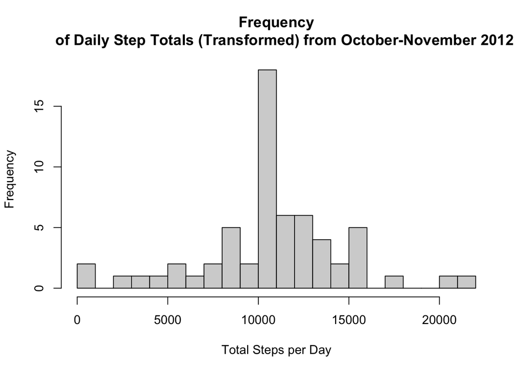

```r
echo = TRUE
# Simple histogram demonstrating the number of steps was close to Mean/Median
# using the transformed data set T_Steps2

hist(T_Steps2$steps, breaks = 16, xlab = "Total Steps per Day", main = "Frequency
    of Daily Step Totals (Transformed) from October-November 2012")
```

Based on this new plot, adding the mean values in place of NA values biased this histogram to have a higher frequency of values close to the mean.

```r
echo = TRUE
# Create a new column in the original data set ActMon flagging the data
# as either Weekday or Weekend, while also making sure that the date
# column is formatted as the "Date" class

ActMon$date <- as.Date(ActMon$date, "%Y-%m-%d")

ActMon$weekendType <- factor(ifelse(weekdays(ActMon$date) %in%
                                  c("Saturday", "Sunday"),
                                "Weekend", "Weekday"))

# Compute the mean of all steps based on the interval in which they occurred,
# then save the output as an object
T_Steps3 <- aggregate(steps ~ date, ActMon, sum)
print(summary(T_Steps3$steps))
```

```
##    Min. 1st Qu.  Median    Mean 3rd Qu.    Max.
##      41    8841   10765   10766   13294   21194
```

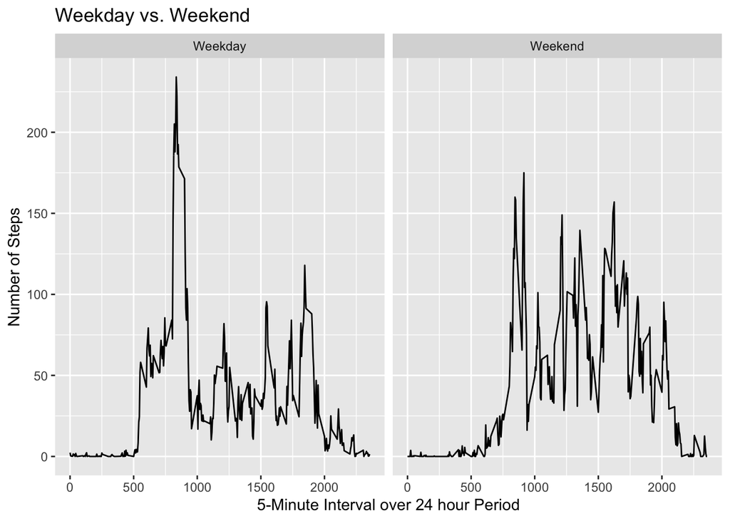

```r
echo = TRUE
# Compute the mean of all steps based on the interval in which they occurred,
# then save the output as an object
Int_Act3 <- aggregate(steps ~ interval + weekendType, ActMon, mean)

# Plot the Weekday vs Weekend graphs of activity data
qplot(interval, steps, data = Int_Act3, facets = .~weekendType,
      geom = "line") +
  xlab("5-Minute Interval over 24 hour Period") +
  ylab("Number of Steps") +
  ggtitle("Weekday vs. Weekend")
```